# Modeling Growth Rates of Fossilized Bivalves Using Bayesian Statistics

### Emma Deering

##### Department of Math, Computer Science, and Statistics; St. Lawrence University; Advised by Dr. Matt Higham

# Abstract

Exploring how growth rates of fossilized clams change across environmental conditions across Northern New York, specifically in regards to acidic vs non acidic bodies of water.

**Key Objectives:**

- Use a Von Bertanfly growth model to model clam growth rates.
- Estimate model parameters using a MCMC algorithm.
- Incorporate a Bayesian framework to account for uncertainty and missing data.

# Data

- Using shell growth rings, the data records how much each clam grew during each annual growth period.
- The data set contains the following useful variables:
  - Location: The lake or river that the clam lived in.
  - Growth Period: Indicates annual stage of growth.
  - Length: Overall length of shell
  - Growth: Total growth during that growth period
  - Body: Indicates if water body was a lake or river.
- Data collected Dr. Judith Nagel-Myers of the St. Lawrence University (Geology).
- 151 valves from 17 different localities.

# Growth Model and Parameters

Von Bertanfly growth model models clam growth as length versus age, capturing decreasing growth rates over time typical of organism development.

$$L(t) = L \cdot (1 - e^{-(k + \beta \cdot x) \cdot (t-t_0)})$$
where

- $t$ is time
- $L(t)$ is mean length at time t
- $L$ is the asymptotic length
- $k$ is the rate
- $\beta$ adjusts the growth rate based on acidity
- $x$ is binary that indicates acidity
- $t_0$ is time where length is 0

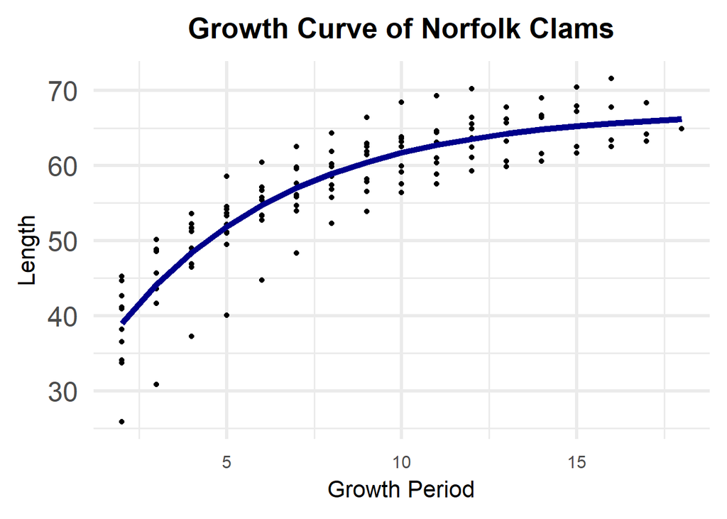

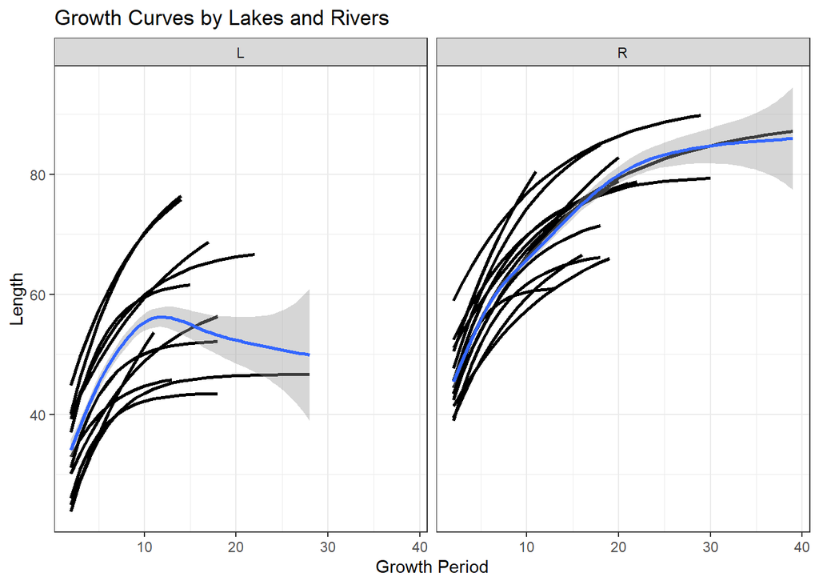

# Bayesian Algorithm

```
## # A tibble: 2 × 6
##   mean_l    sd mean_b mean_sigma2 mean_beta sd_beta
##    <dbl> <dbl>  <dbl>       <dbl>     <dbl>   <dbl>
## 1   56.7  5.45  -1.28       114.     -0.174  0.0798
## 2   86.8  2.32  -6.32        73.1     3.27   2.93
```

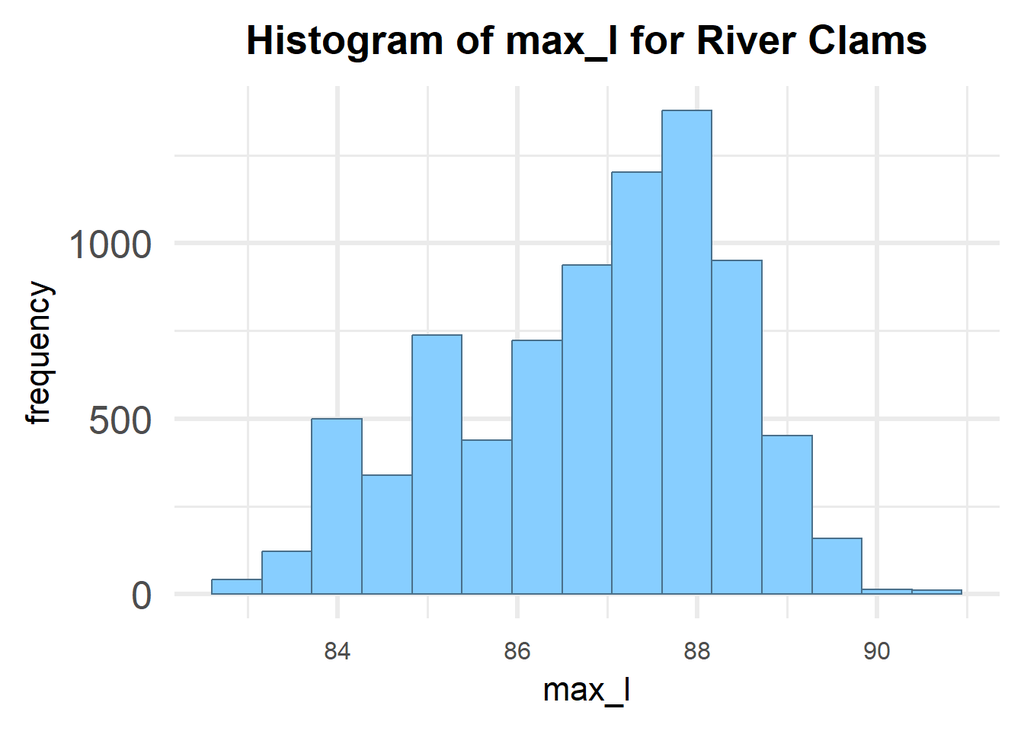

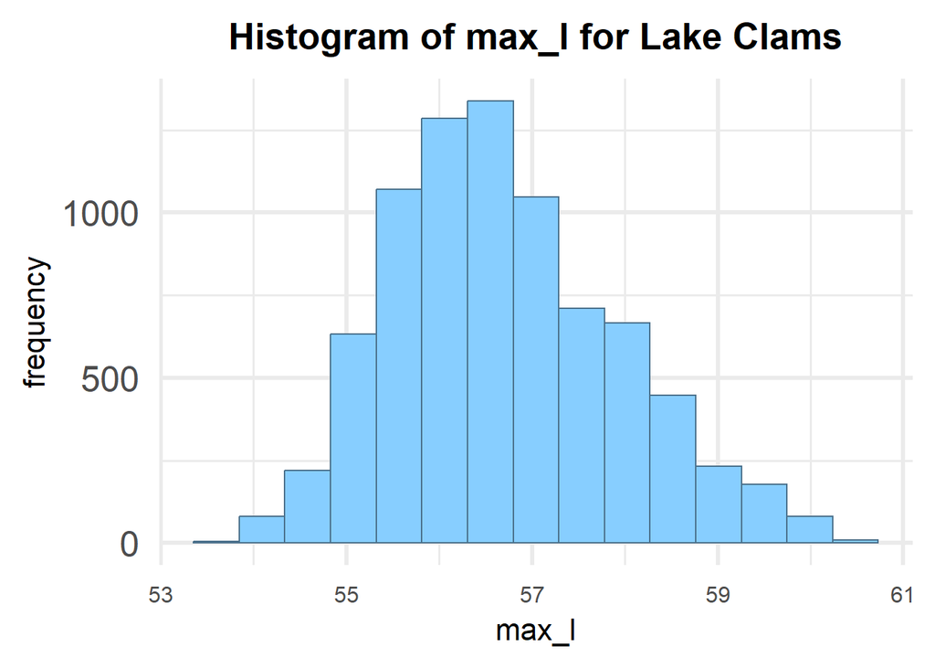

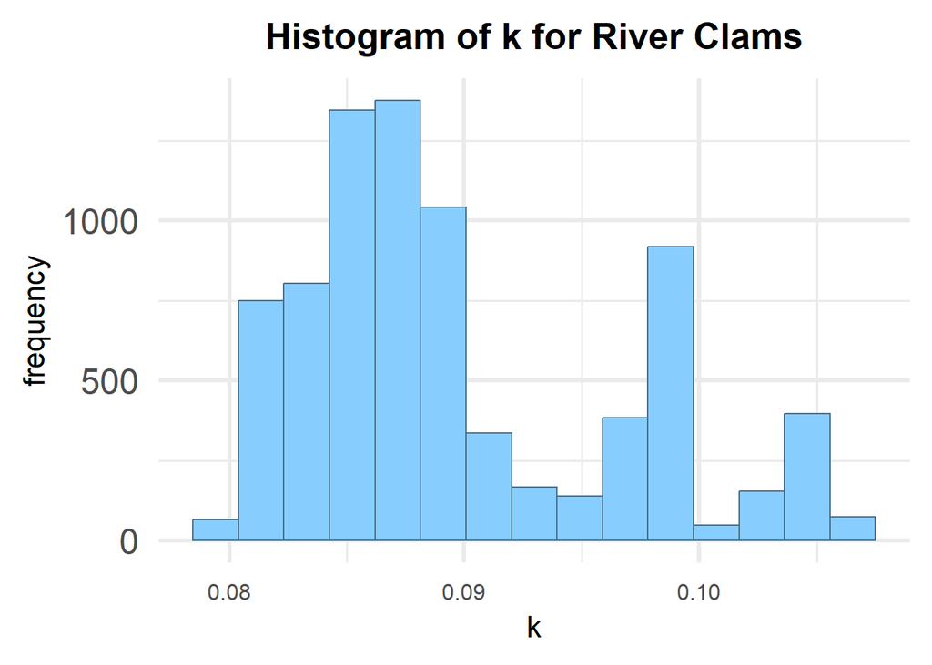